# Análisis

## Prepara los datos

Este código sirve para preparar los datos.

```r
library(poliscidata)

# Crea las bases de países para los ejemplos
w <- world[sample(1:nrow(world), 10),]
w <- world

wa <- w[,c("country","gini10","dem_level4","religoin", "spendhealth")]
wb <- w[,c("country","hdi","pop_urban","lifeex_total", "durable")]

w1 <- w[1:83,]
w2 <- w[84:167,]


# Crea la base de los estados para los ejemplos
d <- states


# Crea la base de los ocupantes del
# Titanic
tt <- data.frame(Titanic)

tt <- tt[rep(row.names(tt), tt$Freq), 1:4]
tt$First_Class <- 0
tt$First_Class[tt$Class=="1st"] <- 1

tt$Crew <- 0
tt$Crew[tt$Class=="Crew"] <- 1
```

## Medidas de Tendencia Central

### ¿Qué es la Tendencia Central?

La tendencia central es una medida que resume la distribución de un conjunto de datos en un solo valor. Las medidas de tendencia central más comunes son la media, la mediana y la moda.

Cuando queremos saber más sobre los estudiantes en clase, por ejemplo, generalmente empleamos algunas señales de información para ayudarnos a comprender un poco mejor quiénes son. La edad es uno de esos tipos de información. Nuestra pregunta es: ¿cuántos años tienen los estudiantes? La composición por sexo es otra: ¿cuántos son mujeres y cuántos son hombres? Sus calificaciones en cursos anteriores también nos ayudan a conocerlos.

Las medidas de tendencia central son herramientas para resumir datos sobre individuos o grupos que nos permiten comprender un poco mejor quiénes son o cuál es el comportamiento esperado en situaciones concretas.

### Medidas de Tendencia Central en R

Usaremos un data.frame llamado **d** basado en el data.frame **states** del paquete *polscidata* para ilustrar los conceptos y realizar ejercicios.

#### **MEDIA**

La función **mean()** calcula el valor promedio o media de una variable dada. Tiene dos parámetros principales a tener en cuenta: x - la variable de la que deseamos calcular la media; y na.rm - indicando si queremos excluir los valores faltantes en el cálculo o no.

Calculemos la media de la variable *unemploy* (% de desempleo en cada Estado) de nuestro data.frame **d**. Recuerda: es necesario usar el signo de dólar ($) después del nombre del data.frame para referirse a una variable. En este caso, sería d$unemploy. Así que hagámoslo:

```r
mean(d$unemploy)
```

```
[1] 5.188
```

El paro medio en los 50 Estados de Estados Unidos es del 5.2 (5.188 para ser exactos).

Ahora, repitamos la operación para la variable *relig_import* (importancia de la religión):

```r
mean(d$relig_import)
```

```
[1] NA
```

Como puedes ver, el resultado fue NA (No Disponible). Verás este acrónimo cada vez que encuentres datos faltantes en R. Para eliminar los casos faltantes, necesitamos usar *na.rm=TRUE* como parámetro.

```r
mean(d$relig_import, na.rm = TRUE)
```

```
[1] 37.31751
```

Ahora, te toca a ti. Calcula la media para las variables *urban* (% de población urbana) y *permit* (% de la población que “Siempre permite” el aborto).

```r
mean(d$urban)
```

```
[1] 71.694
```

```r
mean(d$permit, na.rm = TRUE)
```

```
[1] 36.6875
```

#### **MEDIANA**

La segunda medida es la **mediana**, que separa los valores entre dos grupos con el mismo tamaño. La función es **median()** y tiene los mismos parámetros mencionados para la media: x - la variable de la que deseamos calcular la media; y na.rm - indicando si queremos excluir los valores faltantes en el cálculo o no.

Ahora, en lugar de calcular la media, calculemos la mediana para la variable *unemploy* (% de desempleo en cada Estado) de nuestro data.frame **d**.

```r
median(d$unemploy)
```

```
[1] 5.25
```

La tasa de desempleo mediana, la que separa los 50 Estados de Estados Unidos en dos grupos de 25 estados, es 5.25.

Ahora, repitamos la operación para la variable *relig_import* (importancia de la religión):

```r
median(d$relig_import)
```

```
[1] NA
```

Como puedes ver, el resultado fue NA (No Disponible). Al igual que en el ejemplo anterior, necesitamos usar *na.rm=TRUE* como parámetro.

```r
median(d$relig_import, na.rm = TRUE)
```

```
[1] 33.98906
```

De nuevo, te toca. Calcula la mediana para las variables *urban* (% de población urbana) y *permit* (% de la población que “Siempre permite” el aborto).

```r
median(d$urban)
```

```
[1] 71.5
```

```r
median(d$permit, na.rm = TRUE)
```

```
[1] 35.9
```

#### **MODA**

La tercera medida es la **moda**. Es el valor más frecuente en los datos. Tiene poco sentido calcular la moda para variables continuas, pero puede proporcionar información general para números enteros (la edad más común en un grupo o el número de veces que un equipo nacional de fútbol ganó la Copa del Mundo ;-) ). No hay una función para calcular la moda como tal en R. Podemos hacerlo usando la función **table()** y simplemente seleccionando el valor más alto.

En el fragmento de código a continuación, creo una función llamada **calcMode()** que:

1. cuenta la frecuencia de cada valor de la variable
2. ordena los valores en orden decreciente y selecciona el primer valor
3. devuelve la Moda y su frecuencia.

Ahora, vamos a usarla para calcular la moda de la variable **gunlaw_rank**.

```r
# Crea la función para calcular la moda
calcMode <- function(var){

  # Averigua cuál valor aparece más
  tb <-  sort(table(var), decreasing = T)[1]

  # Informa los resultados
  paste0("Mode: ", names(tb), " - Frequency: ", tb, " times.")

}

# Calcula la moda para la variable gunlaw_rank
calcMode(d$gunlaw_rank)
```

```
[1] "Mode: 36 - Frequency: 6 times."
```

Esta función también se puede usar para variables categóricas. Repitamos el ejercicio para la variable **cig_tax12_3** (Impuestos sobre los cigarrillos):

```r
# Crea la función para calcular la moda
calcMode <- function(var){

  # Averigua cuál valor aparece más
  tb <-  sort(table(var), decreasing = T)[1]

  # Informa los resultados
  paste0("Mode: ", names(tb), " - Frequency: ", tb, " times.")

}

# Calcula la moda para variable cig_tax12_3
calcMode(d$cig_tax12_3)
```

```
[1] "Mode: MidTax - Frequency: 18 times."
```

Es tu turno. Copia la función y calcula la moda para la variable **pot_policy** (Leyes de la marihuana):

```r
# Crea la función para calcular la moda
calcMode <- function(var){

  # Averigua cuál valor aparece más
  tb <-  sort(table(var), decreasing = T)[1]

  # Informa los resultados
  paste0("Mode: ", names(tb), " - Frequency: ", tb, " times.")

}

# Calcula la moda para la variable pot_policy
calcMode(d$pot_policy)
```

```
[1] "Mode: Not legal - Frequency: 18 times."
```

## Medidas de Dispersión: Dispersión y Varianza

### ¿Qué es la Dispersión y la Varianza?

El video a continuación explica las principales medidas de dispersión: rango, rango intercuartil, varianza y desviación estándar.

[video not shown]

### Medidas de Dispersión en R

#### **INTERVALO o RANGO**

La función **range()** calcula el rango para cualquier variable NUMÉRICA dada en un data.frame, y devuelve los valores mínimo y máximo.

```r
range(d$urban)
```

```
[1] 38.2 94.4
```

Ahora calcula el rango para las variables **prochoice** (% de la población pro-elección) y **permit**.

```r
range(d$prochoice)
```

```
[1] 33 70
```

```r
# Puesto que permit contiene casos perdidos,
# resulta importante usar el parámetro na.rm=TRUE
range(d$permit, na.rm = TRUE)
```

```
[1] 15.5 58.5
```

#### **IQR - Rango Intercuartiles**

Mira este breve video para entender cuartiles, percentiles, deciles, etc…

[video not shown]

El código a continuación calcula el rango intercuartil para la variable *urban*.

```r
IQR(d$urban)
```

```
[1] 25.05
```

Ahora, repite la operación para la variable **permit**.

```r
IQR(d$permit,na.rm = TRUE)
```

```
[1] 15.45
```

#### **VARIANZA**

Los mismos principios se aplican a la varianza, calculada por la función **var()**. Los parámetros son los mismos que las funciones **mean()** y **median()**.

Calculemos la varianza de la variable **urban**:

```r
var(d$urban)
```

```
[1] 222.0842
```

Ahora, calcula la varianza de las variables **over64** (% de edad 65 o superior) y **permit**.

```r
var(d$over64)
```

```
[1] 3.034371
```

```r
var(d$permit,na.rm = TRUE)
```

```
[1] 99.15958
```

#### **Desviación Estándar**

La **desviación estándar** es la última medida de dispersión considerada en este tutorial. Se mide en la función **sd()** de R.

Calculemos la desviación estándar de la variable **urban**:

```r
sd(d$urban)
```

```
[1] 14.90249
```

Calcula ahora la desviación estándar de las variables **over64** (% de edad 65 o superior) y **permit**.

```r
sd(d$over64)
```

```
[1] 1.741945
```

```r
sd(d$permit,na.rm = TRUE)
```

```
[1] 9.957891
```

## Trabajando con Datos Categóricos: Frecuencias

### Frecuencias de datos categóricos

Mira el video a continuación para entender cómo calcular datos categóricos:

[video not shown]

### Tablas de Frecuencia en R

Las tablas de frecuencia son la forma más adecuada de resumir datos categóricos. Una vez que tenemos las frecuencias, podemos usarlas para calcular una serie de otras estadísticas e indicadores.

La función **table()** en R devuelve los recuentos de cada categoría en una variable dada. Vamos a usarla para devolver el tipo de política de género que mantienen los EE. UU.:

```r
table(d$gay_policy)
```

```
     Most liberal           Liberal      Conservative Most conservative
                6                14                10                20
```

Como podemos observar, la mayoría de los estados son Conservadores (10) o Muy Conservadores (20). Si quisiéramos expresar estos números en porcentajes, necesitaríamos dividir los resultados por el número total de casos o usar la función **prop.table()**. Hagámoslo:

```r
# Dividiendo los resultados por el total
# de observaciones y, entonces,
# multiplicando por 100
table(d$gay_policy)/sum(table(d$gay_policy))*100
```

```
     Most liberal           Liberal      Conservative Most conservative
               12                28                20                40
```

```r
# Usando la función prop.table() y,
# entonces, multiplicando por 100
prop.table(table(d$gay_policy))*100
```

```
     Most liberal           Liberal      Conservative Most conservative
               12                28                20                40
```

## Explorando la Distribución de Datos en R

### Explorando los data.frames

La síntesis de datos en R se refiere al proceso de reducir un conjunto de datos a un tamaño más manejable mediante la agregación o extracción de información clave de él. Esto se puede hacer utilizando varias funciones de R como **summarize()** y **aggregate()** que le permiten realizar cálculos como la media, la mediana y la desviación estándar en columnas específicas o grupos de datos. Además, la función **describe()** proporciona un resumen rápido de estadísticas básicas para un conjunto de datos dado. Otros paquetes de R como **dplyr** y **tidyr** también proporcionan funciones útiles para la síntesis y manipulación de datos.

Por ejemplo, si tenemos un marco de datos llamado *d* podemos usar el siguiente comando para obtener un resumen del marco de datos:

```r
summary(d)
```

```
     abort_rank3 abortion_rank12  adv_or_more       ba_or_more
 More restr:17   Min.   : 1.00   Min.   : 6.100   Min.   :17.30
 Mid       :17   1st Qu.:13.25   1st Qu.: 7.950   1st Qu.:24.15
 Less restr:16   Median :25.50   Median : 9.200   Median :26.45
                 Mean   :25.50   Mean   : 9.794   Mean   :27.17
                 3rd Qu.:37.75   3rd Qu.:11.000   3rd Qu.:30.35
                 Max.   :50.00   Max.   :16.400   Max.   :38.20

   cig_tax12     cig_tax12_3 conserv_advantage conserv_public
 Min.   :0.170   LoTax :17   Min.   :-2.20     Min.   :26.80
 1st Qu.:0.625   MidTax:18   1st Qu.:10.28     1st Qu.:33.92
 Median :1.349   HiTax :15   Median :19.00     Median :38.65
 Mean   :1.464               Mean   :17.71     Mean   :38.40
 3rd Qu.:2.000               3rd Qu.:25.77     3rd Qu.:42.90
 Max.   :4.350               Max.   :36.00     Max.   :51.40

 dem_advantage      govt_worker         gun_rank3    gun_rank11
 Min.   :-36.700   Min.   :11.50   More restr:15   Min.   : 1.00
 1st Qu.: -4.875   1st Qu.:14.12   Mid       :14   1st Qu.:15.00
 Median :  0.950   Median :15.85   Less restr:21   Median :26.00
 Mean   :  0.948   Mean   :16.61                   Mean   :27.02
 3rd Qu.: 10.925   3rd Qu.:17.77                   3rd Qu.:39.00
 Max.   : 24.000   Max.   :28.00                   Max.   :50.00

  gun_scale11    hr_cons_rank11   hr_conserv11   hr_lib_rank11
 Min.   : 0.00   Min.   : 43.0   Min.   :13.08   Min.   : 51.0
 1st Qu.: 4.00   1st Qu.:150.4   1st Qu.:44.97   1st Qu.:183.7
 Median : 6.50   Median :197.2   Median :56.08   Median :232.3
 Mean   :16.04   Mean   :207.5   Mean   :52.81   Mean   :221.0
 3rd Qu.:15.00   3rd Qu.:244.7   3rd Qu.:65.54   3rd Qu.:277.9
 Max.   :81.00   Max.   :377.5   Max.   :85.38   Max.   :385.0

  hr_liberal11      hs_or_more      obama2012     obama_win12
 Min.   : 14.62   Min.   :79.90   Min.   :24.67   No :24
 1st Qu.: 34.46   1st Qu.:83.97   1st Qu.:40.05   Yes:26
 Median : 44.53   Median :87.50   Median :50.24
 Mean   : 49.26   Mean   :86.87   Mean   :48.16
 3rd Qu.: 55.91   3rd Qu.:89.80   3rd Qu.:55.42
 Max.   :104.49   Max.   :91.80   Max.   :70.55

```

[output cut: 208 more lines]

```
 vep00_turnout   vep04_turnout   vep08_turnout   vep12_turnout
 Min.   :44.20   Min.   :48.20   Min.   :50.50   Min.   :44.20
 1st Qu.:50.10   1st Qu.:57.85   1st Qu.:59.62   1st Qu.:55.70
 Median :56.05   Median :62.75   Median :64.00   Median :59.65
 Mean   :55.83   Mean   :62.18   Mean   :63.46   Mean   :59.94
 3rd Qu.:59.90   3rd Qu.:66.15   3rd Qu.:67.42   3rd Qu.:63.95
 Max.   :69.50   Max.   :78.40   Max.   :78.20   Max.   :75.70

  womleg_2007     womleg_2010     womleg_2011     womleg_2015
 Min.   : 8.80   Min.   :10.00   Min.   : 9.40   Min.   :12.50
 1st Qu.:17.48   1st Qu.:19.62   1st Qu.:19.48   1st Qu.:19.30
 Median :22.70   Median :23.55   Median :23.50   Median :24.40
 Mean   :23.25   Mean   :24.12   Mean   :23.81   Mean   :24.16
 3rd Qu.:29.93   3rd Qu.:28.82   3rd Qu.:28.18   3rd Qu.:28.68
 Max.   :37.80   Max.   :37.50   Max.   :41.00   Max.   :42.00
```

También es posible usar la función **summary()** en columnas específicas de un marco de datos llamando a la función en la columna de interés:

```r
# Resume la variable con el % de personas
# con universidad.
summary(d$college)
```

```
   Min. 1st Qu.  Median    Mean 3rd Qu.    Max.
  17.00   23.12   25.10   25.85   29.00   35.90
```

Vale la pena señalar que la función **summary()** también funciona con otros tipos de objetos de R, como modelos, listas y matrices y la salida puede variar según el tipo de objeto que se le pase.

La función **str()** en R se utiliza para mostrar la estructura interna de un objeto de R. Es una función genérica que se puede utilizar para inspeccionar la estructura de varios tipos de objetos de R, incluyendo vectores, matrices, listas, marcos de datos y modelos.

Cuando se aplica a un data.frame, **str()** devuelve un resumen de la estructura del marco de datos, incluyendo el número de filas y columnas, el nombre de cada columna y las primeras filas de datos. Por ejemplo:

```r
# Tipos de datos
str(d)
```

```
'data.frame':   50 obs. of  135 variables:
 $ abort_rank3      : Factor w/ 3 levels "More restr","Mid",..: 3 2 1 1 3 2 3 2 2 1 ...
 $ abortion_rank12  : num  35 20 4 5 49 25 45 30 26 9 ...
 $ adv_or_more      : num  9 7.7 6.1 9.3 10.7 12.7 15.5 11.4 9 9.9 ...
 $ ba_or_more       : num  26.6 22 18.9 25.6 29.9 35.9 35.6 28.7 25.3 27.5 ...
 $ cig_tax12        : num  2 0.425 1.15 2 0.87 ...
 $ cig_tax12_3      : Factor w/ 3 levels "LoTax","MidTax",..: 3 1 2 3 2 2 3 2 2 1 ...
 $ conserv_advantage: num  21.3 36 26.7 19.5 6.3 15.7 1.8 6.3 17.2 25.8 ...
 $ conserv_public   : num  43.1 44.7 45.2 36 30.8 ...
 $ dem_advantage    : num  -12.2 -14.6 -1.4 -3.5 14.9 -2.4 17 15.9 4.5 -4.7 ...
 $ govt_worker      : num  28 17.5 17.6 15.5 14.9 15.7 15.9 16.1 14.5 17.8 ...
 $ gun_rank3        : Factor w/ 3 levels "More restr","Mid",..: 3 2 3 3 1 1 1 2 3 2 ...
 $ gun_rank11       : num  50 17 39 50 1 15 5 18 41 22 ...
 $ gun_scale11      : num  0 14 4 0 81 15 58 13 3 8 ...
 $ hr_cons_rank11   : num  200 152 132 156 274 ...
```

[output cut: 89 more lines]

Este procedimiento mostrará un resumen de la estructura del marco de datos, incluyendo el número de filas y columnas, el nombre de cada columna, la clase de cada columna y los primeros valores del marco de datos.

Cuando se aplica a un vector o una lista, **str()** devuelve la longitud del objeto, la clase (por ejemplo, “numérico”, “carácter”) y los primeros valores.

La función **str()** es particularmente útil cuando se trabaja con conjuntos de datos grandes o complejos, ya que le permite inspeccionar rápidamente la estructura de los datos e identificar posibles problemas, como datos faltantes o tipos de datos inesperados.

También es importante tener en cuenta que la función **str()** muestra menos información que la función **summary()**, y es más útil cuando el objeto es grande, complicado o cuando se desea mostrar la estructura de los datos sin mostrar los datos en sí.

También podemos aplicar tales funciones a una selección de las variables para evitar devolver información sobre demasiadas variables:

```r
# Selecciona las variables pot_policy y prochoice
summary(d[, c("pot_policy","prochoice")])
```

```
               pot_policy   prochoice
 Not legal          :18   Min.   :33.00
 Pending legis      : 8   1st Qu.:47.00
 Decrim             : 6   Median :55.50
 Medicinal          :10   Mean   :53.66
 Medicinal / Decrim.: 8   3rd Qu.:62.75
                          Max.   :70.00
```

**Ejercicio**

Explore las variables *dem_score14*, *dem_level4*, *hdi*, *gini08*,*religoin*, y *muslim* en el data.frame world (*w*) usando la función *summary()*:

```r
# Resume la base de datos w
summary(w[,c("dem_score14", "dem_level4", "hdi", "gini08","religoin", "muslim")])
```

```
  dem_score14            dem_level4      hdi             gini08
 Min.   :1.080   Full Democ   :24   Min.   :0.1400   Min.   :24.70
 1st Qu.:3.610   Part Democ   :52   1st Qu.:0.4675   1st Qu.:33.48
 Median :5.790   Hybrid       :39   Median :0.6690   Median :39.10
 Mean   :5.548   Authoritarian:52   Mean   :0.6325   Mean   :40.65
 3rd Qu.:7.395                      3rd Qu.:0.7810   3rd Qu.:46.98
 Max.   :9.930                      Max.   :0.9380   Max.   :74.30
                                    NA's   :9        NA's   :45
               religoin  muslim
 Catholic          :52   No :121
 Orthodox Christian:16   Yes: 46
 Other Christian   :27
 Muslim            :46
 Buddhist          :11
 Other             :13
 NA's              : 2
```

### Agregar datos

La agregación de datos se refiere al proceso de recopilar y resumir datos de múltiples fuentes en un conjunto de datos único y consolidado. Esto se puede hacer utilizando varias técnicas, como agrupar datos por ciertas variables, aplicar operaciones matemáticas como suma, promedio o conteo a columnas específicas o combinar datos de múltiples tablas o conjuntos de datos.

La agregación de datos se utiliza a menudo para reducir la complejidad de conjuntos de datos grandes y facilitar el análisis y la visualización de datos. También se puede utilizar para identificar patrones, tendencias y valores atípicos en los datos.

En el R, la agregación de datos se puede realizar utilizando una variedad de funciones y paquetes, como **aggregate()**, **group_by()** y **summarize()** del paquete **dplyr**, **tapply()**, y **by()**. Estas funciones le permiten agrupar datos por ciertas variables y realizar cálculos en columnas específicas.

Por ejemplo, si tenemos un marco de datos con múltiples columnas y queremos calcular la media de algunas columnas y la suma de otras, podemos usar el siguiente comando:

```r
# Selecciona algunas variables de la base de datos d
x <- d[,c("region","vep00_turnout","vep04_turnout","vep08_turnout","vep12_turnout")]

# Calcula la media para dichas variables
aggregate(x,
          by=list(
                  region=x$region),
          mean,
          na.rm=T)
```

```
     region region vep00_turnout vep04_turnout vep08_turnout vep12_turnout
1 Northeast     NA      59.70000      64.78889      65.96667      62.03333
2   Midwest     NA      59.25833      66.30000      66.70000      63.40000
3     South     NA      51.29375      57.98750      60.65000      57.53750
4      West     NA      55.55385      61.71538      62.17692      58.23846
```

**Ejercicio**

Ahora, repita la agregación usando la variable *religoin* para grupos y *hdi*, *gini10*, *dem_score14*,*lifeex_total*, y *frac_eth*.

```r
# Selecciona las variables de w
x <- w[,c("religoin","hdi", "gini10", "dem_score14", "lifeex_total", "frac_eth")]

# Calcula las medias para tales variables
aggregate(x,
          by=list(
                  region=x$religoin),
          mean,
          na.rm=T)
```

```
              region religoin       hdi   gini10 dem_score14 lifeex_total
1           Catholic       NA 0.6840980 42.12000    6.568269     72.25981
2 Orthodox Christian       NA 0.7193750 35.02500    5.843750     71.73533
3    Other Christian       NA 0.5891481 44.08148    6.363704     64.13963
4             Muslim       NA 0.5515366 38.25556    3.806739     67.07556
5           Buddhist       NA 0.6334000 38.91000    4.828182     71.17545
6              Other       NA 0.6487500 36.62308    6.326154     70.82769
   frac_eth
1 0.3860660
2 0.3502231
3 0.4844296
4 0.5359690
5 0.3915778
6 0.4669500
```

**El paquete *dplyr***

Como se mencionó anteriormente, el paquete *dplyr* extiende la funcionalidad básica de R *aggregate()* y nos permite usar varias funciones simultáneamente para agregar los datos en grupos.

```r
# carga el paquete dplyr
library(dplyr)

# Calcula la media POR REGION para vep00_turnout, la
# desviación estándar para vep04_turnout, el valor mínimo
# para vep08_turnout, y el máximo para vep12_turnout
d |>
  group_by(region) |>
  summarize(mean=mean(vep00_turnout),
            sd=sd(vep04_turnout),
            min=min(vep08_turnout),
            max=max(vep12_turnout))
```

```
# A tibble: 4 × 5
  region     mean    sd   min   max
  <fct>     <dbl> <dbl> <dbl> <dbl>
1 Northeast  59.7  5.16  58    70.1
2 Midwest    59.3  6.24  59.4  75.7
3 South      51.3  3.75  50.6  66.4
4 West       55.6  6.73  50.5  70.3
```

Ahora, repita el procedimiento anterior para el conjunto de datos *w* usando la variable *religoin* para grupos y la media para *hdi*, la desviación estándar para *gini10*, la mediana para *dem_score14*, el mínimo para *lifeex_total*, y el máximo para *frac_eth*. No olvide excluir los casos faltantes:

```r
# carga dplyr
library(dplyr)

# Calcula los agregados por religion
w |>
  group_by(religoin) |>
  summarise(m_hdi=mean(hdi, na.rm = T),
            sd_gini=sd(gini10, na.rm=T),
            med_dem=median(dem_score14, na.rm=T),
            min_life=min(lifeex_total, na.rm=T),
            max_frac=max(frac_eth, na.rm=T)
            )
```

```
# A tibble: 7 × 6
  religoin           m_hdi sd_gini med_dem min_life max_frac
  <fct>              <dbl>   <dbl>   <dbl>    <dbl>    <dbl>
1 Catholic           0.684   10.0     6.96     38.8    0.930
2 Orthodox Christian 0.719    7.05    6.28     51.6    0.617
3 Other Christian    0.589   12.1     6.24     48.7    0.908
4 Muslim             0.552    6.26    3.76     45.0    0.862
5 Buddhist           0.633    4.28    4.87     62.4    0.634
6 Other              0.649    6.91    7.63     48.7    0.863
7 <NA>               0.902   NA       4.60     68.9    0.490
```

## Medidas de Asociación

**Antes de empezar**

En los ejercicios diseñados para este tutorial usaremos dos conjuntos de datos. El primero es el data.frame **d** basado en el data.frame **states** del paquete *polscidata* (como en la sección anterior). El segundo es el conjunto de datos **tt** basado en el data.frame Titanic que contiene datos sobre pasajeros y tripulantes del Titanic (Clase, Edad, Sexo, y si sobrevivieron o no).

#### ¿Cómo podemos medir la relación entre variables?

¿Cuál es la relación entre el ejercicio físico y el peso corporal? ¿Y qué hay del tiempo de estudio y las calificaciones? ¿Hay alguna relación entre la educación y los ingresos? ¿La contaminación del aire y las enfermedades respiratorias? Estas preguntas se refieren a la asociación entre diferentes fenómenos. Usualmente usamos este tipo de preguntas cuando tratamos de establecer cómo un evento o atributo impacta en otro.

En estadística, la forma de medir este concepto amplio es la covarianza. Se basa en un principio sencillo: ¿cuánto y en qué dirección cambia la variable *y* cuando la otra variable *x* cambia? Así, si cada año de escolaridad aumenta 100 Euros en ingresos futuros, podemos decir que hay una correlación positiva entre educación e ingresos. Esto se debe a que ambos aumentan. Lo contrario ocurre con el gasto público en saneamiento y la mortalidad infantil. Cuanto más gastan los gobiernos en saneamiento (agua limpia y alcantarillado), menor es el número de muertes en niños pequeños. En este caso, hay una asociación negativa.

Asista al video corto sobre covarianza:

[video not shown]

El coeficiente de correlación de Pearson es una medida de la fuerza y dirección de la relación lineal entre dos variables. En otras palabras, mide cómo se relacionan dos variables cuantitativas. El valor de la correlación de Pearson varía entre -1 y 1. Un valor de 1 indica una correlación positiva perfecta, mientras que un valor de -1 indica una correlación negativa perfecta. Un valor de 0 indica que no hay relación entre las dos variables.

Mira el video corto sobre correlación de Pearson:

[video not shown]

## Mediciones de Asociación en R

En esta sección, exploraremos cómo se pueden calcular en R las dos principales medidas de asociación. La primera es la covarianza y la segunda la correlación. Finalmente, aprenderemos a crear un correlograma, un gráfico que facilita la interpretación de un gran número de variables.

#### **Covarianza**

La covarianza es una medida de la relación entre dos variables. Es similar a la varianza, pero donde la varianza nos dice cómo una sola variable varía, la covarianza nos dice cómo dos variables varían juntas. La covarianza es positiva si las dos variables tienden a aumentar juntas y negativa si una variable disminuye cuando la otra aumenta. La covarianza es cero si no hay relación entre las dos variables.

En R, la función *cov()* es la responsable de calcular la covarianza de dos variables. El fragmento de código a continuación calcula la matriz de covarianza para las variables *unemploy* y *urban*, ambas pertenecientes al data.frame *d*.

```r
cov(d$unemploy, d$urban)
```

```
[1] 1.631967
```

En el siguiente ejemplo, una de las variables *relig_import* (Porcentaje de personas que dicen que la religión juega un papel importante en sus vidas) tiene valores faltantes. Después de ejecutar el código a continuación, puede ver que la primera covarianza devuelve NA. Esto ocurre precisamente porque los NAs no se tratan. En las funciones *mean()*, *median()*, *var()*, y *sd()*, los NAs se manejan utilizando el parámetro “na.rm=T”. En el caso de la covarianza y la correlación, se debe utilizar un nuevo parámetro **use=“pairwise.complete.obs”**. Esta opción le dice a R que solo debe calcular la covarianza (o la correlación) para aquellos pares de valores donde ambos son diferentes de NA.

```r
# Covarianza sin lidiar con casos perdidos NAs
cov(d$unemploy, d$relig_import)
```

```
[1] NA
```

```r
# Covarianza lidiando con NAs
cov(d$unemploy, d$relig_import, use="pairwise.complete.obs")
```

```
[1] 1.538539
```

**Práctica**

Ahora es tu turno. Calcula la covarianza entre las variables *obama08* (% de voto en Obama en 2008) y *obama2012* (% de voto en Obama en 2012) en el data.frame *d*.

```r
cov(d$obama08, d$obama2012)
```

```
[1] 95.55904
```

#### **Correlación**

Distintamente de la covarianza, el **coeficiente de correlación** siempre varía de -1 a 1 independientemente de la escala de las variables empleadas en los cálculos. Por lo tanto, somos capaces de evaluar no solo la dirección, sino también la fuerza de la relación entre estos fenómenos, como ya has visto en los videos.

Ahora, calculemos la correlación entre las variables *abort_rate08* (tasa de aborto en 2008) y *obama08* (% de voto en Obama en 2008) en el data.frame *d*.

```r
cor(d$abort_rate08, d$obama08)
```

```
[1] 0.6415203
```

El resultado es un coeficiente de correlación (r) igual a 0.642. Parece que hay una asociación moderada y positiva entre el aborto y el voto en Obama en 2008. Más claramente, cuanto mayor es la tasa de aborto, mayor es el voto potencial en Obama. La relación no es perfecta (si este fuera el caso, r=1), pero es lo suficientemente fuerte como para llamar nuestra atención sobre la relación entre el aborto y el voto.

Repita el cálculo de correlación anterior, pero ahora use *mccain08* (% de voto en John McCain en 2008) en lugar de *obama08*. ¿Qué obtienes como resultado?

```r
cor(d$abort_rate08, d$mccain08)
```

```
[1] -0.6276876
```

**Correlación de múltiples variables**

En muchas ocasiones queremos realizar muchas correlaciones al mismo tiempo para acelerar el análisis. En esos casos, solo necesitamos proporcionar un data.frame o matriz con SOLO variables numéricas y la función *cor()* devuelve una tabla con todas las correlaciones para estas variables.

```r
# Selecciona algunas variables
# del data.frame d
ds <- d[,c("urban","unemploy",
           "abort_rate08","prcapinc",
           "relig_high","obama08","mccain08")]

# Calcula la correlación para esas
# variables
co <- cor(ds)

# Muestra los resultados
round(co,3)
```

```
              urban unemploy abort_rate08 prcapinc relig_high obama08 mccain08
urban         1.000    0.109        0.663    0.526     -0.227   0.404   -0.404
unemploy      0.109    1.000       -0.040   -0.228      0.208  -0.137    0.134
abort_rate08  0.663   -0.040        1.000    0.589     -0.367   0.642   -0.628
prcapinc      0.526   -0.228        0.589    1.000     -0.643   0.592   -0.590
relig_high   -0.227    0.208       -0.367   -0.643      1.000  -0.682    0.704
obama08       0.404   -0.137        0.642    0.592     -0.682   1.000   -0.997
mccain08     -0.404    0.134       -0.628   -0.590      0.704  -0.997    1.000
```

Como puedes observar, el resultado es una matriz con la correlación entre todas las variables. El coeficiente r para *urban* vs. *urban* es 1.000 porque es la misma variable correlacionada consigo misma. Lo mismo ocurre con todas las demás variables cuando se comparan consigo mismas. El díada *urban* vs. *unemploy*, por otro lado, tiene un r=0.109, una asociación pequeña y positiva. Ahora, *urban* vs. *abort_rate08* presenta un r=0.663, positivo y moderado. El voto en McCain (*mccain08*) está negativamente y fuertemente correlacionado con el voto en Obama en 2008 (*obama08*). Dado que la política de los Estados Unidos es bipartidista, es normal esperar que cuando el voto en un candidato aumenta, el voto en el otro disminuya.

Por lo tanto, tales resultados nos ayudan a identificar aquellas variables con relaciones fuertes (tanto positivas como negativas) y a determinar aquellas que, inicialmente, no parecen estar relacionadas.

## Trabajando con datos categóricos: Frecuencias cruzadas

### Frecuencias de datos categóricos

Visualice el video sobre cómo interpretar tablas de contingencia o frecuencias cruzadas:

[video not shown]

### Tablas de contingencia en R

Tablas de frecuencia son la forma más adecuada de resumir datos categóricos. Una vez que tenemos las frecuencias, podemos usarlas para calcular una serie de otras estadísticas e indicadores. La misma función **table()** utilizada en sesiones anteriores se puede usar para tablas de contingencia para más de una variable categórica.

La función **prop.table()** devuelve la proporción de cada categoría en una celda dada de la tabla:

```r
tb <- table(d$gay_policy, d$region)

prop.table(tb)*100
```

```
                    Northeast Midwest South West
  Most liberal             10       2     0    0
  Liberal                   6       6     2   14
  Conservative              2       6     6    6
  Most conservative         0      10    24    6
```

No obstante, el resultado no es exactamente lo que necesitamos. Los porcentajes son relativos al total y no para la columna o la fila. La apariencia también podría mejorarse significativamente.

La función **crosstable()** del paquete *crosstable* produce una presentación mucho más agradable de los resultados:

```r
library(crosstable)

crosstable(data = d,           # data = nombre del Data frame
           cols = gay_policy,  # cols = Variable(s)
           by= region) %>%     # by = Variable que agrega los resultados
  as_flextable()
```

| label | variable | region Northeast | region Midwest | region South | region West |
| --- | --- | --- | --- | --- | --- |
| gay_policy | Most liberal | 5 (83.33%) | 1 (16.67%) | 0 (0%) | 0 (0%) |
|  | Liberal | 3 (21.43%) | 3 (21.43%) | 1 (7.14%) | 7 (50.00%) |
|  | Conservative | 1 (10.00%) | 3 (30.00%) | 3 (30.00%) | 3 (30.00%) |
|  | Most conservative | 0 (0%) | 5 (25.00%) | 12 (60.00%) | 3 (15.00%) |

Hazlo tú mismo. Usando el código en el fragmento anterior, crea una tabla cruzada para las variables *pot_policy* (Leyes de Marihuana) y *obama_win12* (Obama ganó el Estado en 2012).

```r
library(crosstable)

crosstable(data = d,
           cols = pot_policy,
           by= obama_win12) %>%
  as_flextable()
```

| label | variable | obama_win12 No | obama_win12 Yes |
| --- | --- | --- | --- |
| pot_policy | Not legal | 15 (83.33%) | 3 (16.67%) |
|  | Pending legis | 3 (37.50%) | 5 (62.50%) |
|  | Decrim | 3 (50.00%) | 3 (50.00%) |
|  | Medicinal | 3 (30.00%) | 7 (70.00%) |
|  | Medicinal / Decrim. | 0 (0%) | 8 (100.00%) |

Ahora, empleando los datos del Titanic (tt), crea una tabla de contingencia para las variables *Sex* (Sexo del Pasajero) y *Survived* (Sobrevivió).

```r
library(crosstable)

crosstable(data = tt,
           cols = Sex,
           by= Survived) %>%
  as_flextable()
```

| label | variable | Survived No | Survived Yes |
| --- | --- | --- | --- |
| Sex | Male | 1364 (78.80%) | 367 (21.20%) |
|  | Female | 126 (26.81%) | 344 (73.19%) |

Ahora, repite la operación usando el conjunto de datos del Titanic (tt) para crear una tabla de contingencia para las variables *Class* (Clase del Pasajero) y *Survived*.

```r
library(crosstable)

crosstable(data = tt,
           cols = Class,
           by = Survived) %>%
  as_flextable()
```

| label | variable | Survived No | Survived Yes |
| --- | --- | --- | --- |
| Class | 1st | 122 (37.54%) | 203 (62.46%) |
|  | 2nd | 167 (58.60%) | 118 (41.40%) |
|  | 3rd | 528 (74.79%) | 178 (25.21%) |
|  | Crew | 673 (76.05%) | 212 (23.95%) |

Pongamos un poco de pimienta en el ejercicio. Filtra los datos *tt* para incluir solo miembros de la tripulación en un nuevo data.frame llamado *cw*. Luego, repite la operación usando el conjunto de datos de la tripulación del Titanic (*cw*) para crear una tabla de contingencia para las variables *Sex* (Sexo del miembro de la tripulación) y *Survived*.

```r
# Selecciona solamente los tripulantes
# en el data.frame cw
cw <- tt[tt$Class=="Crew",]

library(crosstable)

crosstable(data = cw,
           cols = Sex,
           by= Survived) %>%
  as_flextable()
```

| label | variable | Survived No | Survived Yes |
| --- | --- | --- | --- |
| Sex | Male | 670 (77.73%) | 192 (22.27%) |
|  | Female | 3 (13.04%) | 20 (86.96%) |

## Hipótesis y Significancia Estadística

El test de hipótesis es un método estadístico utilizado en las ciencias sociales para determinar si hay suficiente evidencia para respaldar una afirmación o hipótesis específica sobre una población. Implica formular una hipótesis nula, que representa la suposición predeterminada o de no diferencia, y una hipótesis alternativa, que representa la afirmación o creencia que se está probando. Luego, se recopila una muestra de datos y se analiza utilizando pruebas estadísticas para determinar la probabilidad de obtener los resultados observados bajo la hipótesis nula. Dependiendo del resultado, la hipótesis nula se acepta o rechaza, proporcionando o no soporte para la hipótesis alternativa.

Algunas aplicaciones específicas de las pruebas de hipótesis en las ciencias sociales incluyen:

1. Prueba de la efectividad de una nueva política o intervención: Los investigadores pueden utilizar la prueba de hipótesis para determinar si una nueva política o intervención tiene el efecto deseado en una población. Por ejemplo, un investigador podría probar la hipótesis de que un nuevo programa educativo conducirá a puntajes más altos en las pruebas entre los estudiantes.
2. Evaluación de la relación entre variables: Los investigadores pueden utilizar la prueba de hipótesis para investigar la relación entre diferentes variables. Por ejemplo, un investigador podría probar la hipótesis de que hay una relación positiva entre el ingreso y la felicidad.
3. Investigación de diferencias entre grupos: Los investigadores pueden utilizar la prueba de hipótesis para determinar si hay diferencias significativas entre diferentes grupos. Por ejemplo, un investigador podría probar la hipótesis de que hay diferencias en los patrones de votación entre hombres y mujeres.
4. Evaluación de la validez de una herramienta de medición: Los investigadores pueden utilizar la prueba de hipótesis para determinar si una herramienta de medición, como una encuesta o cuestionario, es confiable y válida.
5. Exploración del impacto de factores demográficos: Los investigadores pueden utilizar la prueba de hipótesis para investigar el impacto de factores demográficos, como la edad, el género y la raza, en un resultado específico.

## P-values y nivel de significancia

### Hipótesis nula

Una hipótesis nula es una afirmación que representa la suposición predeterminada o de no diferencia en un test de hipótesis. Es la hipótesis que se prueba para determinar si hay suficiente evidencia para rechazarla en favor de la hipótesis alternativa. La hipótesis nula se denota como H0 y generalmente se formula como una afirmación de igualdad. Por ejemplo, una hipótesis nula podría afirmar que no hay diferencia en los puntajes de prueba entre dos grupos de estudiantes.

### Hipótesis alternativa

Una hipótesis alternativa es una afirmación que representa la creencia o afirmación que se está probando en un test de hipótesis. Representa la posibilidad de que haya una diferencia o efecto en la población. La hipótesis alternativa se denota como H1 y generalmente se formula como una afirmación de desigualdad. Por ejemplo, una hipótesis alternativa podría afirmar que hay una diferencia en los puntajes de prueba entre dos grupos de estudiantes.

El objetivo de un test de hipótesis es determinar si hay suficiente evidencia para rechazar la hipótesis nula en favor de la hipótesis alternativa. Si la hipótesis nula se rechaza, significa que hay evidencia para respaldar la hipótesis alternativa. Si la hipótesis nula no se rechaza, significa que no hay suficiente evidencia para respaldar la hipótesis alternativa.

Resulta importante tener en cuenta que un fallo en rechazar la hipótesis nula no significa que la hipótesis nula sea verdadera, sino que la evidencia no es lo suficientemente fuerte como para rechazarla.

### El valor p

El valor p es una medida de la evidencia en contra de una hipótesis nula. Representa la probabilidad de obtener un resultado tan extremo o más extremo que el observado, asumiendo que la hipótesis nula es verdadera.

El valor p se utiliza para determinar si hay suficiente evidencia para rechazar la hipótesis nula en favor de la hipótesis alternativa. Si el valor p es menor que un nivel de significancia predeterminado (generalmente 0.05 o 0.01), se rechaza la hipótesis nula y se acepta la hipótesis alternativa. Si el valor p es mayor que el nivel de significancia, no se rechaza la hipótesis nula.

Por otro lado, un valor p mayor que el nivel de significancia significa que no hay suficiente evidencia para rechazar la hipótesis nula, y los resultados pueden haber ocurrido por casualidad. Por lo tanto, el investigador no rechaza la hipótesis nula.

Es importante tener en cuenta que un valor p bajo no significa que la hipótesis alternativa sea verdadera, sino que hay suficiente evidencia para rechazar la hipótesis nula en favor de la hipótesis alternativa.

También resulta importante señalar que un valor p bajo no significa que la hipótesis sea verdadera, simplemente significa que los datos son poco probables bajo la hipótesis nula.

### Niveles de significancia

Los niveles de significancia se refieren a los niveles de significancia estadística en las pruebas de hipótesis. En las pruebas de hipótesis, un nivel de significancia es un umbral utilizado para determinar si una diferencia o relación observada es estadísticamente significativa. Un nivel de significancia comúnmente utilizado en la investigación es 0.05, lo que significa que hay un 5% de probabilidad de que la diferencia o relación observada sea debida al azar. Si la probabilidad de obtener un resultado tan extremo o más extremo que el observado, si la hipótesis nula es verdadera, es menor o igual al nivel de significancia, se rechaza la hipótesis nula y se acepta la hipótesis alternativa.

Por ejemplo, en un estudio que investiga la relación entre el ingreso y la felicidad, los investigadores podrían utilizar un nivel de significancia de 0.05 para determinar si la relación observada entre el ingreso y la felicidad es estadísticamente significativa. Si la probabilidad de observar una relación tan fuerte o más fuerte que la observada, si la hipótesis nula es verdadera, es menor o igual a 0.05, los investigadores rechazarían la hipótesis nula y concluirían que hay una relación estadísticamente significativa entre el ingreso y la felicidad.

### Video

Asiste al siguiente video para aprender más sobre el concepto de valor p:

[video not shown]

### Ejercicio

1. ¿Es mayor la tasa de abortos en los estados donde Obama ganó en 2008?

Formula la pregunta como un conjunto de hipótesis nula y alternativa:

**H0:** Estados que votaron por Obama y McCain tienen la misma tasa de abortos.

**H1:** Estados donde Obama ganó tienen una tasa de abortos mayor que los estados donde McCain ganó.

```r
# Testa la hipótesis nula de que la tasa de abortos es la misma en los estados donde Obama y McCain ganaron en 2008
tt <- t.test(d$abort_rate08~d$obama_win08)

# Examina el valor p
# Te informa la probabilidad de aceptar
# que H0 sea verdadera:
tt$p.value
```

```
[1] 7.182965e-06
```

```r
# Ahora, redondea a 3 decimales
round(tt$p.value,3)
```

```
[1] 0
```

## El test de Chi-Cuadrado

### Definición

Un test de Chi-Cuadrado es una prueba estadística que se utiliza para determinar si hay una diferencia significativa entre las frecuencias esperadas y observadas en un conjunto de datos categóricos. La prueba se basa en la distribución de Chi-Cuadrado, que es una distribución de probabilidad que describe la distribución de la suma de los cuadrados de k variables normales estándar independientes.

El teste de Chi-Cuadrado es comúnmente utilizado en pruebas de hipótesis para probar la bondad de ajuste de un modelo a los datos observados, o para probar la independencia en una tabla de contingencia.

Cuando se prueba la bondad de ajuste, la hipótesis nula es que los datos siguen una distribución de probabilidad específica, y la hipótesis alternativa es que los datos no siguen esa distribución.

Cuando se prueba la independencia en una tabla de contingencia, la hipótesis nula es que no hay asociación entre las dos variables categóricas y la hipótesis alternativa es que hay una asociación entre las dos variables.

El estadístico de prueba utilizado en un test de Chi-Cuadrado se calcula sumando las diferencias al cuadrado entre las frecuencias observadas y esperadas, divididas por las frecuencias esperadas. El estadístico de prueba calculado se compara entonces con la distribución de Chi-Cuadrado con un cierto grado de libertad para determinar el valor p.

Un valor p menor que un nivel de significancia elegido (generalmente 0.05) se toma como evidencia para rechazar la hipótesis nula y aceptar la hipótesis alternativa.

Es importante tener en cuenta que el test de Chi-Cuadrado asume que el tamaño de la muestra es lo suficientemente grande, de lo contrario no es apropiado utilizarlo.

### Ejemplos

Un ejemplo proviene de la prueba de Independencia en Encuestas de Votantes. Un investigador puede querer probar si la afiliación política de un votante es independiente de su edad. Recopilarían datos sobre la edad y la afiliación política de una muestra de votantes y crearían una tabla de contingencia. La hipótesis nula sería que no hay asociación entre la edad y la afiliación política y la hipótesis alternativa sería que hay una asociación. Se podría utilizar una prueba de Chi-Cuadrado para determinar si las frecuencias observadas difieren significativamente de lo que se esperaría si la hipótesis nula fuera verdadera.

### Video

Asiste al video siguiente sobre el test de Chi-Cuadrado:

[video not shown]

### El Chi-Cuadrado en R

En R, puedes realizar un test de Chi-Cuadrado utilizando la función chisq.test(). La función toma una tabla de contingencia como argumento, que es una tabla que muestra la distribución de frecuencias de dos o más variables categóricas. La tabla de contingencia se puede introducir como una matriz o un data frame.

Por ejemplo, si tenemos un data frame llamado *d* con dos columnas *abort_rank3* y *religiosity3*, y queremos probar si hay una asociación significativa entre las dos variables, usaríamos el siguiente código:

```r
# Realiza el test de chi-cuadrado
chisq.test(d$abort_rank3, d$religiosity3)
```

```
    Pearson's Chi-squared test

data:  d$abort_rank3 and d$religiosity3
X-squared = 23.443, df = 4, p-value = 0.0001033
```

### Ejercicio

**Inténtalo tú**

Empleando nuestros datos sobre países del mundo (*w*), proporciona una respuesta a la siguiente pregunta:

¿Está relacionado el nivel de PIB *per cápita* en 2008 (*gdpcap3_08*) con el tipo de régimen (*dem_level4*)? ¿Varía la riqueza según el tipo de régimen? Recuerda, cada pregunta tiene sus propias hipótesis nula y alternativa:

**H0:** El nivel de riqueza (PIB per cápita) no afecta al tipo de régimen

**H1:** El nivel de riqueza varía según el tipo de régimen

Intenta realizar el test de Chi-Cuadrado en R para probar estas hipótesis:

```r
# Realiza el test chi-cuadrado
chisq.test(w$gdpcap3_08, w$dem_level4)
```

```
    Pearson's Chi-squared test

data:  w$gdpcap3_08 and w$dem_level4
X-squared = 64.821, df = 6, p-value = 4.693e-12
```

## El test t de Student

### Definición

El test t de Student es una prueba estadística utilizada para determinar si hay una diferencia significativa entre las medias de dos grupos. Se utiliza para comparar las medias de dos muestras, cuando las varianzas de las dos poblaciones son desconocidas y el tamaño de la muestra es pequeño. Se basa en la distribución t, que es una distribución de probabilidad que es similar a la distribución normal estándar, pero con una cola ligeramente más plana.

Existen dos tipos de test t: el test t de muestras independientes y el test t de muestras dependientes.

**1. Test t de muestras independientes:** Se utiliza cuando las dos muestras son independientes entre sí, como comparar el PIB per cápita entre dos países diferentes. Por ejemplo, un investigador puede querer comparar el PIB per cápita de Estados Unidos con el de China. La hipótesis nula sería que no hay diferencia en el PIB per cápita entre los dos países y la hipótesis alternativa sería que hay una diferencia.

**2. Test t de muestras dependientes:** Este test se utiliza cuando los dos grupos están relacionados de alguna manera, como comparar el PIB per cápita antes y después de la implementación de una cierta política. Por ejemplo, se puede comparar el PIB per cápita de un país antes y después de la firma de un acuerdo comercial. La hipótesis nula sería que no hay diferencia en el PIB per cápita antes y después del acuerdo comercial y la hipótesis alternativa sería que hay una diferencia.

Resulta importante tener en cuenta que el test t asume que los datos son aproximadamente distribuidos normalmente y que las varianzas de los dos grupos son iguales. Si estas suposiciones no se cumplen, puede ser más apropiado utilizar una prueba no paramétrica como el test de rangos de Wilcoxon (Wilcoxon rank-sum test).

### Video

Asiste al siguiente video sobre el test t:

[video not shown]

### El test t de Student en R

En R, puedes realizar un test t de Student utilizando la función t.test(). La función se puede utilizar para comparar las medias de dos muestras independientes o la media de una sola muestra con un valor conocido.

**Cuestión:** ¿Son los países con mayorías musulmanas menos democráticos que otros?

**Hipótesis:**

**H0:** Los países musulmanes son tan democráticos como los demás países

**H1:** Los países musulmanes son menos democráticos que los demás países

```r
# Ejecuta el test t.
t.test(w$dem_score14~w$muslim, conf.level=0.99)
```

```
    Welch Two Sample t-test

data:  w$dem_score14 by w$muslim
t = 8.6908, df = 120.77, p-value = 2.104e-14
alternative hypothesis: true difference in means between group No and group Yes is not equal to 0
99 percent confidence interval:
 1.679539 3.126983
sample estimates:
 mean in group No mean in group Yes
         6.210000          3.806739
```

## El análisis de varianza (ANOVA)

El ANOVA (Análisis de Varianza) es un método estadístico utilizado para determinar si hay una diferencia significativa entre las medias de dos o más grupos. Se utiliza para comparar las medias de múltiples muestras, cuando las varianzas de las poblaciones son desconocidas y el tamaño de la muestra es pequeño.

Existen tres tipos de ANOVA: ANOVA de un factor, ANOVA de dos factores y ANOVA de varios factores.

**1. ANOVA de un factor:** Se utiliza cuando hay un solo factor o variable independiente, como comparar el PIB per cápita de varios países. Por ejemplo, un investigador puede querer comparar el PIB per cápita de Estados Unidos, China y Japón. La hipótesis nula sería que no hay diferencia en el PIB per cápita entre los tres países y la hipótesis alternativa sería que hay una diferencia.

**2. ANOVA de dos factores:** Este test se utiliza cuando hay dos variables independientes, como comparar el PIB per cápita de varios países antes y después de la implementación de una cierta política. Por ejemplo, un investigador de estudios globales puede querer comparar el PIB per cápita de Estados Unidos, China y Japón antes y después de la firma de un acuerdo comercial. La hipótesis nula sería que no hay diferencia en el PIB per cápita entre los tres países antes y después del acuerdo comercial y la hipótesis alternativa sería que hay una diferencia.

**3. ANOVA de varios factores:** Este test se utiliza cuando hay más de dos variables independientes, como comparar el PIB per cápita de varios países antes y después de la implementación de una cierta política y también el efecto de la población en el PIB per cápita.

Es importante tener en cuenta que el ANOVA asume que los datos están distribuidos normalmente y que las varianzas de los grupos son iguales. Si estas suposiciones no se cumplen, puede ser más apropiado utilizar una prueba no paramétrica como el test de Kruskal-Wallis.

También resulta importante tener en cuenta que estos ejemplos son solo ejemplos y que los resultados del test ANOVA deben ser interpretados cuidadosamente, considerando otros factores como el tamaño de la muestra, la potencia del test y el tamaño del efecto.

### Video

Asiste al siguiente video sobre los tests ANOVA:

[video not shown]

### ANOVA en R

En R, puedes realizar un test ANOVA utilizando las funciones aov() o Anova() del paquete car, o la función oneway.test(). El ANOVA se utiliza para determinar si las medias de dos o más grupos son iguales.

Por ejemplo, si tienes una variable llamada “data” que contiene las respuestas de un experimento, y una variable llamada “group” que indica el grupo al que pertenece cada respuesta, y quieres probar si las medias de los grupos son iguales, utilizarías el siguiente código con la función aov():

```r
# Realiza el análisis
an <- aov(dem_score14~religoin, data = w)

# Recupera los resultados
summary(an)
```

```
             Df Sum Sq Mean Sq F value   Pr(>F)
religoin      5  226.5   45.30    13.5 5.62e-11 ***
Residuals   159  533.5    3.36
---
Signif. codes:  0 '***' 0.001 '**' 0.01 '*' 0.05 '.' 0.1 ' ' 1
2 observations deleted due to missingness
```

La función aov() ajusta un modelo ANOVA a los datos, y la función summary() devuelve un resumen del modelo que incluye el estadístico F y el valor p para el test. El valor p te indica la probabilidad de observar un estadístico F tan extremo o más extremo que el calculado a partir de tus datos, asumiendo que la hipótesis nula (es decir, que las medias de los grupos son iguales) es verdadera. Un valor p pequeño (típicamente menor que 0.05) indica que puedes rechazar la hipótesis nula y concluir que hay una diferencia significativa en las medias entre los grupos.

Si los resultados del ANOVA muestran una diferencia significativa entre los grupos, se recomienda realizar pruebas post-hoc para identificar qué grupos son significativamente diferentes. Hay varias pruebas post-hoc disponibles en R como Tukey HSD, Bonferroni, Scheffe, entre otras.

Un test Tukey HSD es una prueba post-hoc que se utiliza para comparar las medias de múltiples grupos después de que un test ANOVA ha revelado una diferencia significativa entre los grupos. Se utiliza para determinar qué pares específicos de grupos son significativamente diferentes entre sí.

En R, puedes realizar un test Tukey HSD utilizando la función TukeyHSD() del paquete stats. La función toma como entrada el resultado de un test ANOVA.

Por ejemplo, repitamos el ANOVA y agreguemos una prueba Tukey HSD en los grupos:

```r
# Repite el test ANOVA
an <- aov(dem_score14~religoin, data = w)

# Realiza el test Tukey HSD con un nivel
# de significancia de 99% o p=0.01.
tk<-TukeyHSD(an, conf.level = 0.99)

# Guarda los resultados en un  data.frame
dtk <- data.frame(tk$religoin)

# Redondea los valores para facilitar la interpretación
dtk$p.adj <- round(dtk$p.adj,3)

# Muestra los resultados
dtk
```

```
                                          diff        lwr        upr p.adj
Orthodox Christian-Catholic        -0.72451923 -2.5181276  1.0690891 0.737
Other Christian-Catholic           -0.20456553 -1.6927776  1.2836465 0.997
Muslim-Catholic                    -2.76153010 -4.0314235 -1.4916367 0.000
Buddhist-Catholic                  -1.74008741 -3.8222138  0.3420390 0.053
Other-Catholic                     -0.24211538 -2.1875568  1.7033260 0.998
Other Christian-Orthodox Christian  0.51995370 -1.4594172  2.4993246 0.946
Muslim-Orthodox Christian          -2.03701087 -3.8579346 -0.2160871 0.002
Buddhist-Orthodox Christian        -1.01556818 -3.4728806  1.4417442 0.718
Other-Orthodox Christian            0.48240385 -1.8602178  2.8250255 0.981
Muslim-Other Christian             -2.55696457 -4.0779864 -1.0359427 0.000
Buddhist-Other Christian           -1.53552189 -3.7796539  0.7086101 0.183
Other-Other Christian              -0.03754986 -2.1554782  2.0803785 1.000
Buddhist-Muslim                     1.02144269 -1.0842597  3.1271451 0.559
Other-Muslim                        2.51941472  0.5487613  4.4900681 0.000
Other-Buddhist                      1.49797203 -1.0722606  4.0682046 0.349
```

### El gráfico Tukey HSD

Un gráfico Tukey HSD, también conocido como un gráfico de comparación múltiple de Tukey, es una representación gráfica de los resultados de una prueba Tukey HSD. Se utiliza para comparar visualmente las medias de múltiples grupos e identificar qué pares específicos de grupos son significativamente diferentes entre sí.

Un gráfico de Tukey HSD típicamente consiste en una serie de líneas, una para cada grupo. Las líneas muestran los valores mínimo y máximo del intervalo de confianza generado por la prueba. El punto en el centro de la línea es la diferencia media entre los dos grupos que se están comparando.

El gráfico de Tukey HSD también suele incluir asteriscos, letras u otros símbolos para identificar qué pares específicos de grupos son significativamente diferentes entre sí.

En R, hay muchas formas diferentes de generar un gráfico Tukey HSD. No obstante, dado que utilizaremos el ambiente ggplot en todos nuestros tutoriales (y en el curso de visualización de datos), emplearemos aquí la función ggHSD() del paquete ggiraphExtra:

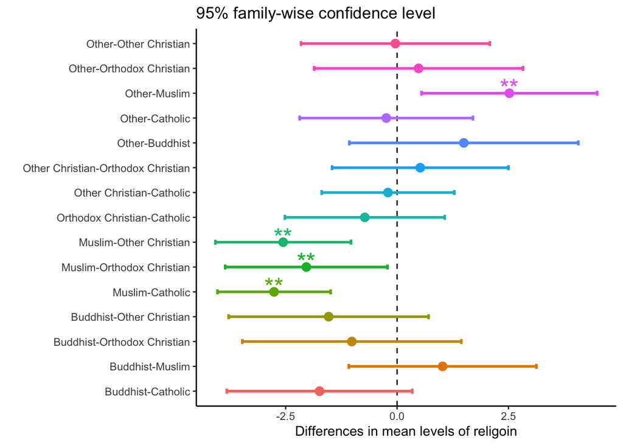

```r
# Carga los paquetes
library(ggplot2)
library(ggiraphExtra)

# Repite el test de ANOVA
an <- aov(dem_score14~religoin, data = w)

# Realiza el test Tukey HSD con un nivel
# de significancia de 99% o p=0.01.
tk<-TukeyHSD(an, conf.level = 0.99)


# Crea un gráfico que representa los
# intervalos de confianza informados
# por el test Tukey HSD
ggHSD(tk) +
    theme(axis.text.y = element_text(angle = 0, hjust = 1, size = 10))+
    theme_classic()
```

### Ejercicio

Ahora te toca a ti.

Primero, repite el test ANOVA y agrega una prueba Tukey HSD para los grupos *dem_score14* y *gdp_cap3* del conjunto de datos *w*.

```r
# Realiza el análisis
an <- aov(dem_score14~gdp_cap3, data = w)

# Muestra los resultados
summary(an)
```

```
             Df Sum Sq Mean Sq F value   Pr(>F)
gdp_cap3      2  215.4  107.71   33.19 1.32e-12 ***
Residuals   146  473.9    3.25
---
Signif. codes:  0 '***' 0.001 '**' 0.01 '*' 0.05 '.' 0.1 ' ' 1
18 observations deleted due to missingness
```

Segundo, genera las diferencias para cada par de categorías utilizando el test Tukey HSD:

```r
# Repite el test de ANOVA
an <- aov(dem_score14~gdp_cap3, data = w)

# Realiza el test Tukey HSD con un nivel
# de significancia de 99% o p=0.01.
tk<-TukeyHSD(an, conf.level = 0.99)

# Guarda los resultados en un  data.frame
dtk <- data.frame(tk$gdp_cap3)

# Redondea los valores para facilitar la interpretación
dtk$p.adj <- round(dtk$p.adj,3)

# Muestra los resultados
dtk
```

```
                diff         lwr      upr p.adj
Middle-Low  1.018329 -0.04407901 2.080738 0.014
High-Low    2.896038  1.83362933 3.958446 0.000
High-Middle 1.877708  0.78932033 2.966096 0.000
```

Tercero, crea el gráfico para representar los coeficientes:

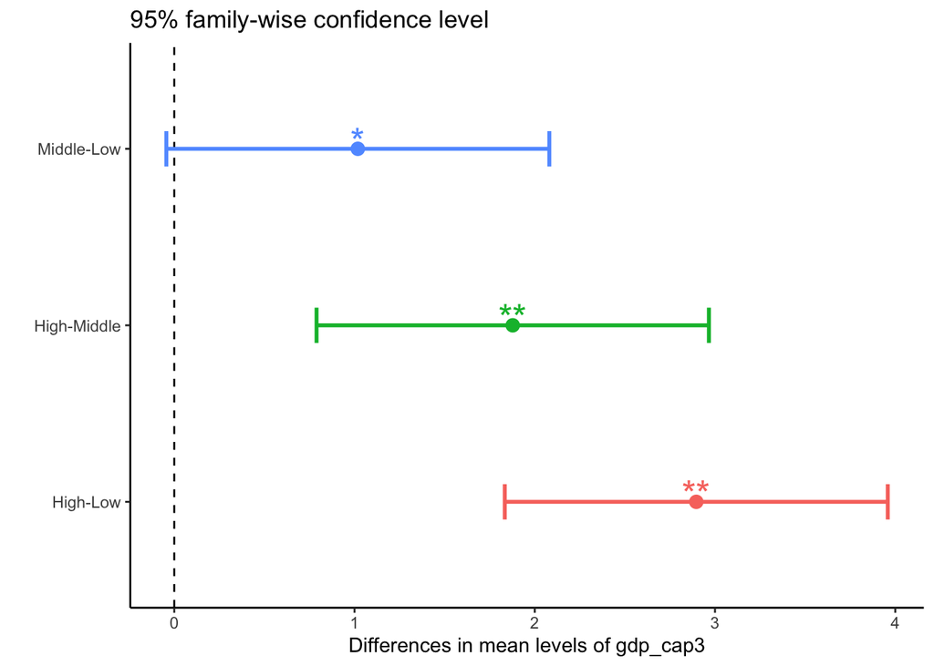

```r
# Carga los paquetes
library(ggplot2)
library(ggiraphExtra)

# Repite el test de ANOVA
an <- aov(dem_score14~gdp_cap3, data = w)

# Realiza el test Tukey HSD con un nivel
# de significancia de 99% o p=0.01.
tk<-TukeyHSD(an, conf.level = 0.99)

# Crea un gráfico que representa los
# intervalos de confianza informados
# por el test Tukey HSD
ggHSD(tk) +
    theme(axis.text.y = element_text(angle = 0, hjust = 1, size = 10))+
    theme_classic()
```